# Исследование объявлений о продаже квартир

В вашем распоряжении данные сервиса Яндекс.Недвижимость — архив объявлений о продаже квартир в Санкт-Петербурге и соседних населённых пунктах за несколько лет. Нужно научиться определять рыночную стоимость объектов недвижимости. Ваша задача — установить параметры. Это позволит построить автоматизированную систему: она отследит аномалии и мошенническую деятельность.

По каждой квартире на продажу доступны два вида данных. Первые вписаны пользователем, вторые получены автоматически на основе картографических данных. Например, расстояние до центра, аэропорта, ближайшего парка и водоёма.

**Цель исследования**:

1. Определить рыночную стоимость объектов недвижимости.
2. Построить автоматизированную систему, которая отследит аномалии и мошенническую деятельность.
3. Установить, какие факторы влияют на ценообразование стоимости квартир.

   **Ход исследования**

   Данные о недвижимости я получу из файла `'/datasets/real_estate_data.csv'`. О качестве данных ничего не известно. Поэтому перед тем, как приступать к целям исследования, понадобится обзор данных.

   Я проверю данные на ошибки и оценю их влияние на исследование. Затем, на этапе предобработки я поищу возможность исправить все ошибки данных, которые не приведут к искажению конечного результата. Далее, создам необходимые столбцы, и приступлю к проведению исследовательского анализа.

   Таким образом, моё исследование пройдёт в семь этапов:
   - Обзор данных.
   - Предобработка данных.
   - Расчеты и добавление результатов в таблицу.
   - Проведение анализа для Ленинградской области.
   - Проведение анализа для Санкт-Петербурга.
   - Различаются ли факторы, которые влияют на ценообразование стоимости квартир.
   - Написание общего вывода.

## Изучение данных из файла

```python
import pandas as pd # импортирую библиотеку pandas
df = pd.read_csv('/datasets/real_estate_data.csv', sep='\t')
import warnings # игнорирование ошибок
warnings.filterwarnings('ignore')
import matplotlib # импорт библиотек для работы с графиками
import matplotlib.pyplot as plt
import numpy as np
import seaborn as sns
```

```python
df.head(15) # Выведем первые 15 строк и изучим их
```

|  | total_images | last_price | total_area | first_day_exposition | rooms | ceiling_height | floors_total | living_area | floor | is_apartment | ... | kitchen_area | balcony | locality_name | airports_nearest | cityCenters_nearest | parks_around3000 | parks_nearest | ponds_around3000 | ponds_nearest | days_exposition |
| --- | --- | --- | --- | --- | --- | --- | --- | --- | --- | --- | --- | --- | --- | --- | --- | --- | --- | --- | --- | --- | --- |
| 0 | 20 | 13000000.0 | 108.00 | 2019-03-07T00:00:00 | 3 | 2.70 | 16.0 | 51.00 | 8 | NaN | ... | 25.00 | NaN | Санкт-Петербург | 18863.0 | 16028.0 | 1.0 | 482.0 | 2.0 | 755.0 | NaN |
| 1 | 7 | 3350000.0 | 40.40 | 2018-12-04T00:00:00 | 1 | NaN | 11.0 | 18.60 | 1 | NaN | ... | 11.00 | 2.0 | посёлок Шушары | 12817.0 | 18603.0 | 0.0 | NaN | 0.0 | NaN | 81.0 |
| 2 | 10 | 5196000.0 | 56.00 | 2015-08-20T00:00:00 | 2 | NaN | 5.0 | 34.30 | 4 | NaN | ... | 8.30 | 0.0 | Санкт-Петербург | 21741.0 | 13933.0 | 1.0 | 90.0 | 2.0 | 574.0 | 558.0 |
| 3 | 0 | 64900000.0 | 159.00 | 2015-07-24T00:00:00 | 3 | NaN | 14.0 | NaN | 9 | NaN | ... | NaN | 0.0 | Санкт-Петербург | 28098.0 | 6800.0 | 2.0 | 84.0 | 3.0 | 234.0 | 424.0 |
| 4 | 2 | 10000000.0 | 100.00 | 2018-06-19T00:00:00 | 2 | 3.03 | 14.0 | 32.00 | 13 | NaN | ... | 41.00 | NaN | Санкт-Петербург | 31856.0 | 8098.0 | 2.0 | 112.0 | 1.0 | 48.0 | 121.0 |
| 5 | 10 | 2890000.0 | 30.40 | 2018-09-10T00:00:00 | 1 | NaN | 12.0 | 14.40 | 5 | NaN | ... | 9.10 | NaN | городской посёлок Янино-1 | NaN | NaN | NaN | NaN | NaN | NaN | 55.0 |
| 6 | 6 | 3700000.0 | 37.30 | 2017-11-02T00:00:00 | 1 | NaN | 26.0 | 10.60 | 6 | NaN | ... | 14.40 | 1.0 | посёлок Парголово | 52996.0 | 19143.0 | 0.0 | NaN | 0.0 | NaN | 155.0 |
| 7 | 5 | 7915000.0 | 71.60 | 2019-04-18T00:00:00 | 2 | NaN | 24.0 | NaN | 22 | NaN | ... | 18.90 | 2.0 | Санкт-Петербург | 23982.0 | 11634.0 | 0.0 | NaN | 0.0 | NaN | NaN |
| 8 | 20 | 2900000.0 | 33.16 | 2018-05-23T00:00:00 | 1 | NaN | 27.0 | 15.43 | 26 | NaN | ... | 8.81 | NaN | посёлок Мурино | NaN | NaN | NaN | NaN | NaN | NaN | 189.0 |
| 9 | 18 | 5400000.0 | 61.00 | 2017-02-26T00:00:00 | 3 | 2.50 | 9.0 | 43.60 | 7 | NaN | ... | 6.50 | 2.0 | Санкт-Петербург | 50898.0 | 15008.0 | 0.0 | NaN | 0.0 | NaN | 289.0 |
| 10 | 5 | 5050000.0 | 39.60 | 2017-11-16T00:00:00 | 1 | 2.67 | 12.0 | 20.30 | 3 | NaN | ... | 8.50 | NaN | Санкт-Петербург | 38357.0 | 13878.0 | 1.0 | 310.0 | 2.0 | 553.0 | 137.0 |
| 11 | 9 | 3300000.0 | 44.00 | 2018-08-27T00:00:00 | 2 | NaN | 5.0 | 31.00 | 4 | False | ... | 6.00 | 1.0 | Ломоносов | 48252.0 | 51677.0 | 0.0 | NaN | 0.0 | NaN | 7.0 |
| 12 | 10 | 3890000.0 | 54.00 | 2016-06-30T00:00:00 | 2 | NaN | 5.0 | 30.00 | 5 | NaN | ... | 9.00 | 0.0 | Сертолово | NaN | NaN | NaN | NaN | NaN | NaN | 90.0 |
| 13 | 20 | 3550000.0 | 42.80 | 2017-07-01T00:00:00 | 2 | 2.56 | 5.0 | 27.00 | 5 | NaN | ... | 5.20 | 1.0 | Петергоф | 37868.0 | 33058.0 | 1.0 | 294.0 | 3.0 | 298.0 | 366.0 |
| 14 | 1 | 4400000.0 | 36.00 | 2016-06-23T00:00:00 | 1 | NaN | 6.0 | 17.00 | 1 | NaN | ... | 8.00 | 0.0 | Пушкин | 20782.0 | 30759.0 | 0.0 | NaN | 1.0 | 96.0 | 203.0 |

15 rows × 22 columns

```python
df.info() #Получение информамации о таблице
```

```
<class 'pandas.core.frame.DataFrame'>
RangeIndex: 23699 entries, 0 to 23698
Data columns (total 22 columns):
total_images            23699 non-null int64
last_price              23699 non-null float64
total_area              23699 non-null float64
first_day_exposition    23699 non-null object
rooms                   23699 non-null int64
ceiling_height          14504 non-null float64
floors_total            23613 non-null float64
living_area             21796 non-null float64
floor                   23699 non-null int64
is_apartment            2775 non-null object
studio                  23699 non-null bool
open_plan               23699 non-null bool
kitchen_area            21421 non-null float64
balcony                 12180 non-null float64
locality_name           23650 non-null object
airports_nearest        18157 non-null float64
cityCenters_nearest     18180 non-null float64
parks_around3000        18181 non-null float64
parks_nearest           8079 non-null float64
ponds_around3000        18181 non-null float64
ponds_nearest           9110 non-null float64
days_exposition         20518 non-null float64
dtypes: bool(2), float64(14), int64(3), object(3)
memory usage: 3.7+ MB
```

Вывод:

В предоставленной таблице: 22 колонки, 23699 строк(записей). 4 типа данных `int64` `float64` `object` `bool`.

- `airports_nearest` — расстояние до ближайшего аэропорта в метрах (м)
- `balcony` — число балконов
- `ceiling_height` — высота потолков (м)
- `cityCenters_nearest` — расстояние до центра города (м)
- `days_exposition` — сколько дней было размещено объявление (от публикации до снятия)
- `first_day_exposition` — дата публикации
- `floor` — этаж
- `floors_total` — всего этажей в доме
- `is_apartment` — апартаменты (булев тип)
- `kitchen_area` — площадь кухни в квадратных метрах (м²)
- `last_price` — цена на момент снятия с публикации
- `living_area` — жилая площадь в квадратных метрах (м²)
- `locality_name` — название населённого пункта
- `open_plan` — свободная планировка (булев тип)
- `parks_around3000` — число парков в радиусе 3 км
- `parks_nearest` — расстояние до ближайшего парка (м)
- `ponds_around3000` — число водоёмов в радиусе 3 км
- `ponds_nearest` — расстояние до ближайшего водоёма (м)
- `rooms` — число комнат
- `studio` — квартира-студия (булев тип)
- `total_area` — площадь квартиры в квадратных метрах (м²)
- `total_images` — число фотографий квартиры в объявлении

В предоставленных ниже столбцах, имеются пропуски значений

`Parks_nearest`, `ponds_nearest` и `airports_nearest` - кол-во пропусков разное. Предпологаю, что продавцы не специльно не указали в объявлинии, по той причине, что не знают, какое расстояние до ближайшего пруда или аэропорта (Возьмем к примеру отдаленый поселок, где аэропорт находится в 5 часах езды - трудно указать расстояние до аэропорта). Человек спепецильно не указал.

Столбцы `locality_name`, `floors_total` и `living_area` первые 2 имеют пропуска лишь в 0.4% датасета. Считаю, что природа этих пропусков заключается в том, что продавцы случайно не указали эти данные (ведь, они являются основной информацией для покупателя).

Столбец `balcony`, имеет сугубо человеческий фактор. Т.к. пропуски из-за того, что балкон отсутствует как таковой, и оставили пропуск.

Больше всего пропусков в столбце `is_apartment`. Считаю, что природа незаполнения - не является технической. И из-за того, что квартира не является апартаментом и соответственно пропустили этот столбец при введении данных недвижимости.

Есть колонки с некорректным типом данных, которые в дальнейшем нужно изменить.

## Предобработка данных

### Обработка пропусков

Посчитаем, сколько в таблице пропущенных значений.

```python
df.isna().sum()
```

```
total_images                0
last_price                  0
total_area                  0
first_day_exposition        0
rooms                       0
ceiling_height           9195
floors_total               86
living_area              1903
floor                       0
is_apartment            20924
studio                      0
open_plan                   0
kitchen_area             2278
balcony                 11519
locality_name              49
airports_nearest         5542
cityCenters_nearest      5519
parks_around3000         5518
parks_nearest           15620
ponds_around3000         5518
ponds_nearest           14589
days_exposition          3181
dtype: int64
```

Выведем на экран значения, которые показывают % пропусков в каждом столбце DataFrame

```python
pd.DataFrame(round(df.isna().mean()*100,)).style.background_gradient('coolwarm')
```

|  | 0 |
| --- | --- |
| total_images | 0 |
| last_price | 0 |
| total_area | 0 |
| first_day_exposition | 0 |
| rooms | 0 |
| ceiling_height | 39 |
| floors_total | 0 |
| living_area | 8 |
| floor | 0 |
| is_apartment | 88 |
| studio | 0 |
| open_plan | 0 |
| kitchen_area | 10 |
| balcony | 49 |
| locality_name | 0 |
| airports_nearest | 23 |
| cityCenters_nearest | 23 |
| parks_around3000 | 23 |
| parks_nearest | 66 |
| ponds_around3000 | 23 |
| ponds_nearest | 62 |
| days_exposition | 13 |

Первым делом, нужно удалить пропуски в столбце `locality_name`(название населённого пункта). Т.к. заменить их не получится.

```python
df = (df.dropna(subset=['locality_name'])).reset_index(drop=True)
```

Удалим строки с долей пропусков менее 10 %

```python
df = (df.dropna(subset=['locality_name'])).reset_index(drop=True)
```

```python
df = (df.dropna(subset=['floors_total'])).reset_index(drop=True)
```

Если продавец не указал число балконов, то скорее всего их нет. Правильнее будет заменить на 0

```python
df['balcony'] = df['balcony'].fillna(0)
```

```python
df['is_apartment'] = df['is_apartment'].fillna(False)
```

Проверим значения высоты потолков, на наличие аномальных значений:

```python
df[df['ceiling_height']>=20]
```

|  | total_images | last_price | total_area | first_day_exposition | rooms | ceiling_height | floors_total | living_area | floor | is_apartment | ... | kitchen_area | balcony | locality_name | airports_nearest | cityCenters_nearest | parks_around3000 | parks_nearest | ponds_around3000 | ponds_nearest | days_exposition |
| --- | --- | --- | --- | --- | --- | --- | --- | --- | --- | --- | --- | --- | --- | --- | --- | --- | --- | --- | --- | --- | --- |
| 353 | 17 | 3600000.0 | 55.2 | 2018-07-12T00:00:00 | 2 | 25.0 | 5.0 | 32.0 | 2 | False | ... | NaN | 2.0 | Гатчина | NaN | NaN | NaN | NaN | NaN | NaN | 259.0 |
| 3134 | 14 | 2900000.0 | 75.0 | 2018-11-12T00:00:00 | 3 | 32.0 | 3.0 | 53.0 | 2 | False | ... | 8.0 | 0.0 | Волхов | NaN | NaN | NaN | NaN | NaN | NaN | NaN |
| 4621 | 0 | 4300000.0 | 45.0 | 2018-02-01T00:00:00 | 2 | 25.0 | 9.0 | 30.0 | 2 | False | ... | 7.0 | 1.0 | Санкт-Петербург | 12016.0 | 13256.0 | 1.0 | 658.0 | 1.0 | 331.0 | 181.0 |
| 4852 | 7 | 3000000.0 | 25.0 | 2017-09-27T00:00:00 | 0 | 27.0 | 25.0 | 17.0 | 17 | False | ... | NaN | 2.0 | посёлок Мурино | NaN | NaN | NaN | NaN | NaN | NaN | 28.0 |
| 5051 | 0 | 3850000.0 | 30.5 | 2018-10-03T00:00:00 | 1 | 24.0 | 5.0 | 19.5 | 1 | True | ... | 5.5 | 0.0 | Санкт-Петербург | 29686.0 | 8389.0 | 3.0 | 397.0 | 1.0 | 578.0 | 7.0 |
| 5219 | 0 | 2500000.0 | 54.0 | 2017-10-13T00:00:00 | 2 | 27.0 | 5.0 | 30.0 | 3 | False | ... | 9.0 | 2.0 | деревня Мины | NaN | NaN | NaN | NaN | NaN | NaN | 540.0 |
| 5641 | 4 | 4400000.0 | 50.0 | 2017-08-08T00:00:00 | 2 | 26.0 | 9.0 | 21.3 | 3 | False | ... | 7.0 | 2.0 | Санкт-Петербург | 28981.0 | 10912.0 | 1.0 | 305.0 | 0.0 | NaN | 267.0 |
| 5777 | 17 | 8150000.0 | 80.0 | 2019-01-09T00:00:00 | 2 | 27.0 | 36.0 | 41.0 | 13 | False | ... | 12.0 | 5.0 | Санкт-Петербург | 18732.0 | 20444.0 | 0.0 | NaN | 3.0 | 80.0 | 38.0 |
| 6213 | 6 | 3300000.0 | 44.4 | 2019-03-25T00:00:00 | 2 | 25.0 | 5.0 | 31.3 | 5 | False | ... | 5.7 | 0.0 | Кронштадт | 68923.0 | 50649.0 | 1.0 | 417.0 | 2.0 | 73.0 | NaN |
| 9334 | 5 | 3950000.0 | 42.0 | 2017-03-26T00:00:00 | 3 | 25.0 | 5.0 | 30.0 | 2 | False | ... | 5.2 | 0.0 | Санкт-Петербург | 11647.0 | 13581.0 | 0.0 | NaN | 0.0 | NaN | NaN |
| 10713 | 8 | 3800000.0 | 58.0 | 2017-10-13T00:00:00 | 2 | 27.0 | 10.0 | 30.1 | 3 | False | ... | 8.1 | 2.0 | посёлок Мурино | NaN | NaN | NaN | NaN | NaN | NaN | 71.0 |
| 11221 | 0 | 1950000.0 | 37.0 | 2019-03-20T00:00:00 | 1 | 25.0 | 5.0 | 17.0 | 4 | False | ... | 9.0 | 2.0 | Луга | NaN | NaN | NaN | NaN | NaN | NaN | 18.0 |
| 14298 | 9 | 1700000.0 | 35.0 | 2015-12-04T00:00:00 | 1 | 25.0 | 5.0 | 20.0 | 2 | False | ... | 8.0 | 1.0 | поселок Новый Свет | NaN | NaN | NaN | NaN | NaN | NaN | 206.0 |
| 17399 | 15 | 6700000.0 | 92.9 | 2019-02-19T00:00:00 | 3 | 20.0 | 17.0 | 53.2 | 14 | False | ... | 12.0 | 5.0 | Санкт-Петербург | 16295.0 | 15092.0 | 1.0 | 967.0 | 0.0 | NaN | NaN |
| 17756 | 1 | 3900000.0 | 56.0 | 2017-12-22T00:00:00 | 3 | 27.0 | 5.0 | 33.0 | 4 | False | ... | NaN | 0.0 | Санкт-Петербург | 41030.0 | 15543.0 | 0.0 | NaN | 0.0 | NaN | 73.0 |
| 18442 | 6 | 3750000.0 | 43.0 | 2019-03-18T00:00:00 | 2 | 25.0 | 5.0 | 29.0 | 3 | False | ... | NaN | 0.0 | Санкт-Петербург | 27054.0 | 8033.0 | 1.0 | 540.0 | 0.0 | NaN | 12.0 |
| 20364 | 11 | 8000000.0 | 45.0 | 2017-07-18T00:00:00 | 1 | 27.0 | 4.0 | 22.0 | 2 | False | ... | 10.0 | 1.0 | Санкт-Петербург | 18975.0 | 3246.0 | 0.0 | NaN | 3.0 | 449.0 | 429.0 |
| 20393 | 12 | 5950000.0 | 60.0 | 2018-02-19T00:00:00 | 2 | 22.6 | 14.0 | 35.0 | 11 | False | ... | 13.0 | 1.0 | Санкт-Петербург | 27028.0 | 12570.0 | 0.0 | NaN | 0.0 | NaN | 40.0 |
| 21256 | 19 | 4900000.0 | 42.0 | 2017-04-18T00:00:00 | 1 | 27.5 | 24.0 | 37.7 | 19 | False | ... | 11.0 | 2.0 | Санкт-Петербург | 42742.0 | 9760.0 | 0.0 | NaN | 0.0 | NaN | 61.0 |
| 21700 | 20 | 2450000.0 | 44.0 | 2019-02-12T00:00:00 | 2 | 27.0 | 2.0 | 38.0 | 2 | False | ... | 8.6 | 2.0 | городской поселок Большая Ижора | NaN | NaN | NaN | NaN | NaN | NaN | NaN |
| 22211 | 19 | 9999000.0 | 92.4 | 2019-04-05T00:00:00 | 2 | 32.0 | 6.0 | 55.5 | 5 | False | ... | 16.5 | 4.0 | Санкт-Петербург | 18838.0 | 3506.0 | 0.0 | NaN | 3.0 | 511.0 | NaN |
| 22739 | 0 | 15000000.0 | 25.0 | 2018-07-25T00:00:00 | 1 | 100.0 | 5.0 | 14.0 | 5 | True | ... | 11.0 | 5.0 | Санкт-Петербург | 34963.0 | 8283.0 | 1.0 | 223.0 | 3.0 | 30.0 | 19.0 |
| 22807 | 14 | 4000000.0 | 98.0 | 2018-03-15T00:00:00 | 4 | 27.0 | 2.0 | 73.0 | 2 | True | ... | 9.0 | 1.0 | деревня Нижняя | NaN | NaN | NaN | NaN | NaN | NaN | 27.0 |

23 rows × 22 columns

Выяснили, что в DF имется недвижимость со 100 метровыми потолками. Возможно кто-то считал в дециметрах, переведем в стандартные метры:

```python
def correct_сeiling_height(i): #функция, для перевода в метры
    if i >= 20:
        i = i/10
    return i
df['ceiling_height'] = df['ceiling_height'].apply(correct_сeiling_height) # заменим на нормальные значения
```

Заполним пропуски в высоте потолков в зависимости от населенного пункта (в каждом районе строят квартиры с одниковыми потолками, поэтому считаю, что нужно заменить пропуски таким образом).

```python
for locality_name in df['locality_name'].unique():
    median = df.loc[df['locality_name'] == locality_name,'ceiling_height'].median()
    df.loc[(df['ceiling_height'].isna()) & (df['locality_name'] == locality_name), 'ceiling_height'] = median

# все что не заполнилось заполняем общей медианой по Лен. области (121 пропуск заменим медианой)
df.loc[df['ceiling_height'].isna(), 'ceiling_height'] = df['ceiling_height'].median()
```

Заполняем пропуски в расстоянии до центра в зависимости от населенного пункта. Если останутся пропуски, то будет некорректно до-заполнять медианой).

```python
for locality_name in df['locality_name'].unique():
    median = df.loc[df['locality_name'] == locality_name,'cityCenters_nearest'].median()
    df.loc[(df['cityCenters_nearest'].isna()) & (df['locality_name'] == locality_name), 'cityCenters_nearest'] = median
```

Проверим столбец rooms:

```python
df['rooms'].value_counts()
```

```
1     8004
2     7897
3     5779
4     1172
5      325
0      194
6      104
7       59
8       12
9        8
10       3
14       2
11       2
19       1
12       1
16       1
15       1
Name: rooms, dtype: int64
```

Есть строки, где 0 комнат. Скорее всего это обычная студия, и переведем в 1-комнатную недвижимость.

```python
df['rooms'] = df['rooms'].replace(0,1)
```

Проверим наличие дубликатов:

```python
df.duplicated().sum()
```

```
0
```

Для некоторых типов данных нет подходящих значений под замену. В этом случае, правильнее оставить эти значения пустыми, чем запонять медианой.

Дубликаты отсутствуют

### Замена типа данных

Проверим, какие типы данных представлены в таблице.

```python
df.info()
```

```
<class 'pandas.core.frame.DataFrame'>
RangeIndex: 23565 entries, 0 to 23564
Data columns (total 22 columns):
total_images            23565 non-null int64
last_price              23565 non-null float64
total_area              23565 non-null float64
first_day_exposition    23565 non-null object
rooms                   23565 non-null int64
ceiling_height          23565 non-null float64
floors_total            23565 non-null float64
living_area             21700 non-null float64
floor                   23565 non-null int64
is_apartment            23565 non-null bool
studio                  23565 non-null bool
open_plan               23565 non-null bool
kitchen_area            21343 non-null float64
balcony                 23565 non-null float64
locality_name           23565 non-null object
airports_nearest        18041 non-null float64
cityCenters_nearest     18133 non-null float64
parks_around3000        18065 non-null float64
parks_nearest           8030 non-null float64
ponds_around3000        18065 non-null float64
ponds_nearest           9036 non-null float64
days_exposition         20394 non-null float64
dtypes: bool(3), float64(14), int64(3), object(2)
memory usage: 3.5+ MB
```

Для дальнейшей работы, нам нужно столбцы: `balcony`,`floors_total` нужно перевести из `float64` в целочесленный формат - `int`. Так, же присвоить `is_apartment` булевый тип и перевести дату в другой формат времени.

`last_price` переведем в млн. руб

```python
df['balcony'] = df['balcony'].astype('int')
```

```python
df['last_price'] = (df['last_price']/1000000).round(1)
```

```python
df['floors_total'] = df['floors_total'].astype('int')
```

```python
df['is_apartment'] = df['is_apartment'].astype(bool)
```

```python
df['first_day_exposition'] = pd.to_datetime(df['first_day_exposition'], format = '%Y-%m-%d')
```

Проверим:

```python
df.info()
```

```
<class 'pandas.core.frame.DataFrame'>
RangeIndex: 23565 entries, 0 to 23564
Data columns (total 22 columns):
total_images            23565 non-null int64
last_price              23565 non-null float64
total_area              23565 non-null float64
first_day_exposition    23565 non-null datetime64[ns]
rooms                   23565 non-null int64
ceiling_height          23565 non-null float64
floors_total            23565 non-null int64
living_area             21700 non-null float64
floor                   23565 non-null int64
is_apartment            23565 non-null bool
studio                  23565 non-null bool
open_plan               23565 non-null bool
kitchen_area            21343 non-null float64
balcony                 23565 non-null int64
locality_name           23565 non-null object
airports_nearest        18041 non-null float64
cityCenters_nearest     18133 non-null float64
parks_around3000        18065 non-null float64
parks_nearest           8030 non-null float64
ponds_around3000        18065 non-null float64
ponds_nearest           9036 non-null float64
days_exposition         20394 non-null float64
dtypes: bool(3), datetime64[ns](1), float64(12), int64(5), object(1)
memory usage: 3.5+ MB
```

Вывод: Колличество балконов и этажей принято считать без дробной части. Ведь цена за квартиру в любом денежном эквиваленте (рубли, евро или доллары) принято считать без копеек.

Изменить тип данных можно двумя способами:

- Метод `to_numeric()`. Его особенность заключается в том, что при переводе, все числа будут иметь тип данных float.
- Метод `astype()`. С помощью этого метода, переводят в нужный тип данных.

Изходя из вышеизложенного. Нам подходит метод `astype()`.

Столбец `first_day_exposition` был переведен в другой формат (без-часовой), т.к. в исходной таблице часы указаны нулями(00:00:00).

## Расчёты и добавление результатов в таблицу

### Добавим в таблицу цену квадратного метра;

```python
df['price_per_square_meter'] = df['last_price']/df['total_area']
```

Проверим файл:

```python
df.head()
```

|  | total_images | last_price | total_area | first_day_exposition | rooms | ceiling_height | floors_total | living_area | floor | is_apartment | ... | balcony | locality_name | airports_nearest | cityCenters_nearest | parks_around3000 | parks_nearest | ponds_around3000 | ponds_nearest | days_exposition | price_per_square_meter |
| --- | --- | --- | --- | --- | --- | --- | --- | --- | --- | --- | --- | --- | --- | --- | --- | --- | --- | --- | --- | --- | --- |
| 0 | 20 | 13.0 | 108.0 | 2019-03-07 | 3 | 2.700 | 16 | 51.0 | 8 | False | ... | 0 | Санкт-Петербург | 18863.0 | 16028.0 | 1.0 | 482.0 | 2.0 | 755.0 | NaN | 0.120370 |
| 1 | 7 | 3.4 | 40.4 | 2018-12-04 | 1 | 2.615 | 11 | 18.6 | 1 | False | ... | 2 | посёлок Шушары | 12817.0 | 18603.0 | 0.0 | NaN | 0.0 | NaN | 81.0 | 0.084158 |
| 2 | 10 | 5.2 | 56.0 | 2015-08-20 | 2 | 2.700 | 5 | 34.3 | 4 | False | ... | 0 | Санкт-Петербург | 21741.0 | 13933.0 | 1.0 | 90.0 | 2.0 | 574.0 | 558.0 | 0.092857 |
| 3 | 0 | 64.9 | 159.0 | 2015-07-24 | 3 | 2.700 | 14 | NaN | 9 | False | ... | 0 | Санкт-Петербург | 28098.0 | 6800.0 | 2.0 | 84.0 | 3.0 | 234.0 | 424.0 | 0.408176 |
| 4 | 2 | 10.0 | 100.0 | 2018-06-19 | 2 | 3.030 | 14 | 32.0 | 13 | False | ... | 0 | Санкт-Петербург | 31856.0 | 8098.0 | 2.0 | 112.0 | 1.0 | 48.0 | 121.0 | 0.100000 |

5 rows × 23 columns

### Добавим в таблицу день недели, месяц и год публикации объявления

```python
df['weekday'] = df['first_day_exposition'].dt.weekday # добавим в DF столбец 'неделя'
```

```python
df['month'] = df['first_day_exposition'].dt.month # добавим в DF столбец 'месяц'
#df['month'] = df['first_day_exposition'].astype('datetime64[M]').astype(int) % 12+1
```

```python
df['year'] = df['first_day_exposition'].dt.year # добавим в DF столбец 'год'
```

```python
df.sort_values(by='month')
```

|  | total_images | last_price | total_area | first_day_exposition | rooms | ceiling_height | floors_total | living_area | floor | is_apartment | ... | cityCenters_nearest | parks_around3000 | parks_nearest | ponds_around3000 | ponds_nearest | days_exposition | price_per_square_meter | weekday | month | year |
| --- | --- | --- | --- | --- | --- | --- | --- | --- | --- | --- | --- | --- | --- | --- | --- | --- | --- | --- | --- | --- | --- |
| 11782 | 13 | 9.9 | 75.2 | 2016-01-29 | 2 | 3.20 | 6 | 33.0 | 2 | False | ... | 2152.0 | 2.0 | 604.0 | 3.0 | 65.0 | 324.0 | 0.131649 | 4 | 1 | 2016 |
| 20164 | 8 | 3.4 | 34.3 | 2017-01-09 | 1 | 2.70 | 4 | 15.0 | 1 | False | ... | 1938.0 | 2.0 | 396.0 | 3.0 | 438.0 | 115.0 | 0.099125 | 0 | 1 | 2017 |
| 20178 | 3 | 4.6 | 35.0 | 2018-01-11 | 1 | 2.70 | 25 | NaN | 7 | False | ... | 9238.0 | 0.0 | NaN | 1.0 | 293.0 | 60.0 | 0.131429 | 3 | 1 | 2018 |
| 10046 | 9 | 7.4 | 70.0 | 2016-01-27 | 3 | 2.60 | 3 | 46.5 | 2 | False | ... | 26589.0 | 3.0 | 200.0 | 3.0 | 652.0 | 301.0 | 0.105714 | 2 | 1 | 2016 |
| 13795 | 14 | 4.6 | 45.8 | 2017-01-09 | 2 | 2.70 | 9 | 28.7 | 7 | False | ... | 15500.0 | 1.0 | 812.0 | 0.0 | NaN | 52.0 | 0.100437 | 0 | 1 | 2017 |
| ... | ... | ... | ... | ... | ... | ... | ... | ... | ... | ... | ... | ... | ... | ... | ... | ... | ... | ... | ... | ... | ... |
| 4279 | 14 | 3.4 | 31.8 | 2017-12-14 | 1 | 2.55 | 5 | 17.2 | 1 | False | ... | 5982.0 | 0.0 | NaN | 1.0 | 567.0 | 5.0 | 0.106918 | 3 | 12 | 2017 |
| 11401 | 10 | 8.5 | 80.6 | 2017-12-06 | 4 | 2.70 | 5 | 52.6 | 5 | False | ... | 4602.0 | 0.0 | NaN | 1.0 | 953.0 | 72.0 | 0.105459 | 2 | 12 | 2017 |
| 13971 | 8 | 1.1 | 30.5 | 2017-12-26 | 1 | 2.55 | 5 | 23.0 | 5 | False | ... | NaN | NaN | NaN | NaN | NaN | 150.0 | 0.036066 | 1 | 12 | 2017 |
| 21949 | 12 | 6.7 | 52.0 | 2018-12-11 | 2 | 2.65 | 12 | 28.0 | 5 | False | ... | 12180.0 | 0.0 | NaN | 0.0 | NaN | 118.0 | 0.128846 | 1 | 12 | 2018 |
| 8298 | 20 | 4.7 | 44.4 | 2017-12-25 | 1 | 2.70 | 10 | 18.6 | 7 | False | ... | 10255.0 | 0.0 | NaN | 1.0 | 1223.0 | 73.0 | 0.105856 | 0 | 12 | 2017 |

23565 rows × 26 columns

```python
df.head(10)
```

|  | total_images | last_price | total_area | first_day_exposition | rooms | ceiling_height | floors_total | living_area | floor | is_apartment | ... | cityCenters_nearest | parks_around3000 | parks_nearest | ponds_around3000 | ponds_nearest | days_exposition | price_per_square_meter | weekday | month | year |
| --- | --- | --- | --- | --- | --- | --- | --- | --- | --- | --- | --- | --- | --- | --- | --- | --- | --- | --- | --- | --- | --- |
| 0 | 20 | 13.0 | 108.00 | 2019-03-07 | 3 | 2.700 | 16 | 51.00 | 8 | False | ... | 16028.0 | 1.0 | 482.0 | 2.0 | 755.0 | NaN | 0.120370 | 3 | 3 | 2019 |
| 1 | 7 | 3.4 | 40.40 | 2018-12-04 | 1 | 2.615 | 11 | 18.60 | 1 | False | ... | 18603.0 | 0.0 | NaN | 0.0 | NaN | 81.0 | 0.084158 | 1 | 12 | 2018 |
| 2 | 10 | 5.2 | 56.00 | 2015-08-20 | 2 | 2.700 | 5 | 34.30 | 4 | False | ... | 13933.0 | 1.0 | 90.0 | 2.0 | 574.0 | 558.0 | 0.092857 | 3 | 8 | 2015 |
| 3 | 0 | 64.9 | 159.00 | 2015-07-24 | 3 | 2.700 | 14 | NaN | 9 | False | ... | 6800.0 | 2.0 | 84.0 | 3.0 | 234.0 | 424.0 | 0.408176 | 4 | 7 | 2015 |
| 4 | 2 | 10.0 | 100.00 | 2018-06-19 | 2 | 3.030 | 14 | 32.00 | 13 | False | ... | 8098.0 | 2.0 | 112.0 | 1.0 | 48.0 | 121.0 | 0.100000 | 1 | 6 | 2018 |
| 5 | 10 | 2.9 | 30.40 | 2018-09-10 | 1 | 2.600 | 12 | 14.40 | 5 | False | ... | NaN | NaN | NaN | NaN | NaN | 55.0 | 0.095395 | 0 | 9 | 2018 |
| 6 | 6 | 3.7 | 37.30 | 2017-11-02 | 1 | 2.640 | 26 | 10.60 | 6 | False | ... | 19143.0 | 0.0 | NaN | 0.0 | NaN | 155.0 | 0.099196 | 3 | 11 | 2017 |
| 7 | 5 | 7.9 | 71.60 | 2019-04-18 | 2 | 2.700 | 24 | NaN | 22 | False | ... | 11634.0 | 0.0 | NaN | 0.0 | NaN | NaN | 0.110335 | 3 | 4 | 2019 |
| 8 | 20 | 2.9 | 33.16 | 2018-05-23 | 1 | 2.700 | 27 | 15.43 | 26 | False | ... | NaN | NaN | NaN | NaN | NaN | 189.0 | 0.087455 | 2 | 5 | 2018 |
| 9 | 18 | 5.4 | 61.00 | 2017-02-26 | 3 | 2.500 | 9 | 43.60 | 7 | False | ... | 15008.0 | 0.0 | NaN | 0.0 | NaN | 289.0 | 0.088525 | 6 | 2 | 2017 |

10 rows × 26 columns

Для упрощения дальнейших исследований, необходимо, чтобы в стобцах которые показываю дату, выводились понятные значения (т.е. не 0, а понедельник и т.д.). Применим метод `map()`.

```python
weekday_dict = {0: 'пнд', 1: 'вт', 2: 'ср', 3: 'чт', 4: 'пт', 5: 'сб', 6: 'вс'} #присваиваем переменной weekday_dict день недели
df['weekday'] = df['weekday'].map(weekday_dict) # присваиваем столбцу 'weekday' переменную
```

```python
month_dick = {1: 'Январь',2: 'Февраль',3: 'Март',4: 'Апрель',5: 'Май',6: 'Июнь',7: 'Июль',8: 'Август',9: 'Сентябрь',10: 'Октябрь',11: 'Ноябрь',12: 'Декабрь'}
df['month'] = df['month'].map(month_dick)
```

Проверим результат:

```python
df.head(3)
```

|  | total_images | last_price | total_area | first_day_exposition | rooms | ceiling_height | floors_total | living_area | floor | is_apartment | ... | cityCenters_nearest | parks_around3000 | parks_nearest | ponds_around3000 | ponds_nearest | days_exposition | price_per_square_meter | weekday | month | year |
| --- | --- | --- | --- | --- | --- | --- | --- | --- | --- | --- | --- | --- | --- | --- | --- | --- | --- | --- | --- | --- | --- |
| 0 | 20 | 13.0 | 108.0 | 2019-03-07 | 3 | 2.700 | 16 | 51.0 | 8 | False | ... | 16028.0 | 1.0 | 482.0 | 2.0 | 755.0 | NaN | 0.120370 | чт | Март | 2019 |
| 1 | 7 | 3.4 | 40.4 | 2018-12-04 | 1 | 2.615 | 11 | 18.6 | 1 | False | ... | 18603.0 | 0.0 | NaN | 0.0 | NaN | 81.0 | 0.084158 | вт | Декабрь | 2018 |
| 2 | 10 | 5.2 | 56.0 | 2015-08-20 | 2 | 2.700 | 5 | 34.3 | 4 | False | ... | 13933.0 | 1.0 | 90.0 | 2.0 | 574.0 | 558.0 | 0.092857 | чт | Август | 2015 |

3 rows × 26 columns

### Посчитаем и добавим в таблицу - этаж квартиры (первый, последний, другой);

Автоматизируем построение нового столбца:

```python
def number_of_floors (i):
    floors_total = i['floors_total']
    floor=i['floor']
    if floor == 1:
        return 'первый'
    if floor == floors_total:
        return 'последний'
    if 1 < floor < floors_total:
        return 'другой'

# Создадим новый столбец, который показывает варианта этажа (первый, последний или другой)
df['level'] = df.apply(number_of_floors, axis = 1)
```

### Добавим соотношение жилой и общей площади, а также отношение площади кухни к общей.

```python
df['liv_coef'] = df['living_area']/df['total_area'] #создадим коэффициенты, чтоб уточнить данные
df['kit_coef'] = df['kitchen_area']/df['total_area']#разделив площади (жилые и кухни) на общую
```

Проверим:

```python
df.head(3)
```

|  | total_images | last_price | total_area | first_day_exposition | rooms | ceiling_height | floors_total | living_area | floor | is_apartment | ... | ponds_around3000 | ponds_nearest | days_exposition | price_per_square_meter | weekday | month | year | level | liv_coef | kit_coef |
| --- | --- | --- | --- | --- | --- | --- | --- | --- | --- | --- | --- | --- | --- | --- | --- | --- | --- | --- | --- | --- | --- |
| 0 | 20 | 13.0 | 108.0 | 2019-03-07 | 3 | 2.700 | 16 | 51.0 | 8 | False | ... | 2.0 | 755.0 | NaN | 0.120370 | чт | Март | 2019 | другой | 0.472222 | 0.231481 |
| 1 | 7 | 3.4 | 40.4 | 2018-12-04 | 1 | 2.615 | 11 | 18.6 | 1 | False | ... | 0.0 | NaN | 81.0 | 0.084158 | вт | Декабрь | 2018 | первый | 0.460396 | 0.272277 |
| 2 | 10 | 5.2 | 56.0 | 2015-08-20 | 2 | 2.700 | 5 | 34.3 | 4 | False | ... | 2.0 | 574.0 | 558.0 | 0.092857 | чт | Август | 2015 | другой | 0.612500 | 0.148214 |

3 rows × 29 columns

Вывод: По итогу были построены новые данные, которые крайне необходимы для выявления целей проекта

## Исследовательский анализ данных

### Изучение основных параметров и построение для них гистограмм

Для дальнейшего исследования необходимо изучить: цену, площадь, кол-во комнат и высоту потолков. Автоматизируем построение гистограмм для этих данных:

```python
def column_visible(df, column, bins, range1, suptitle, xlabel, ylabel):

    plt.figure(figsize=(40,5)) # размер фигуры
    plt.suptitle(suptitle + ' [' + column + ']', fontsize=16) # название фигуры

    # первая фигура hist()
    plt.subplot(1, 2, 1) # выделим место в фигуре
    plt.hist(df[column], bins=bins, range = range1)
    plt.xlabel(xlabel) # название оси x
    plt.ylabel(ylabel) # название оси y
    plt.grid(axis = 'both') # отображение сетки


    # вывод фигуры
    plt.show()
```

Выведем 4 гистограммы, для изучения нужных данных:

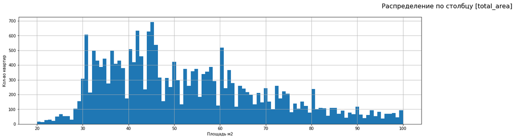

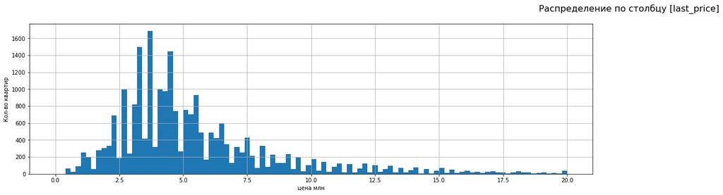

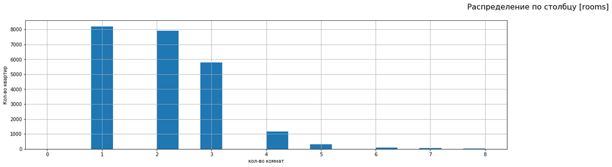

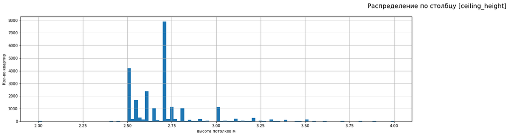

```python
column_visible(df, 'total_area', 100, (20,100), 'Распределение по столбцу', 'Площадь м2', 'Кол-во квартир') # общая площадь
column_visible(df, 'last_price', 100, (0,20), 'Распределение по столбцу', 'цена млн', 'Кол-во квартир') # цена
column_visible(df, 'rooms', 20, (0,8), 'Распределение по столбцу', 'кол-во комнат', 'Кол-во квартир') #кол-во комнат
column_visible(df, 'ceiling_height', 100, (2,4), 'Распределение по столбцу', 'высота потолков м', 'Кол-во квартир') #высота потолков
```

- Наблюдаем самый пик в области 30-60 м2. Редкая недвижимость попадается после 180м2, но считать это аномальными значениями категорически нельзя (например большой загородный дом на 250м2 считается нормой).
- По цене наблюдаем среднюю строимость недвижимость от 3млн до 5млн. Так же видим, что с увеличением цены падает кол-во предложений (тут можно посмотреть среднюю платёжеспособность за квартиру граждан в Ленинградской области). Считаю нормой, аномалий не наблюдаю.
- На гистограмме показывающей кол-во комнат, всё нормально (пик приходится на 1/2/3 команатную квартиру, как и распространено в повседневной жизни). Но нужно проверить на наличие выбросов (неадекватных значений, но их значение может быть мало, что не отображается на гистограмме).
- Пик наблюдается на отметке в от 2 до 2.8 метра. Имеются объявления с 2ух метровыми поталками, такое действительно бывает (редко!), в очень старых постройках.

### Время продажи квартиры

Высчитаем среднюю и медианную, и построим график для времени продажи относительно кол-ва квартир:

```python
print(df['days_exposition'].mean())
print(df['days_exposition'].median())
```

```
180.7413945278023
95.0
```

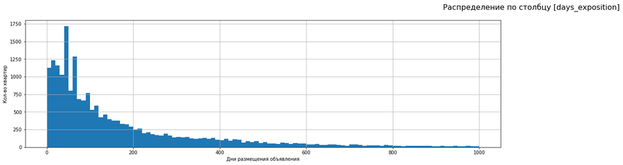

```python
column_visible(df, 'days_exposition', 100, (0,1000), 'Распределение по столбцу', 'Дни размещения объявления', 'Кол-во квартир')
```

### Уберём редкие и выбивающиеся значения

```python
df = (df[(df['days_exposition'] > 0)]).reset_index(drop=True)
```

Проверим явные выбросы на блочном графика и удалим их. Для этого автоматизируем построение блочного графика и :

```python
def yashik_s_ysami(df, column, bins, suptitle, xlabel):

    plt.figure(figsize=(16,5)) # размер фигуры
    plt.suptitle(suptitle + ' [' + column + ']', fontsize=16) # название фигуры


    # вторая фигура boxplot()
    plt.subplot(1, 2, 2) # выделим место в фигуре
    plt.boxplot(df[column], vert=False)
    plt.xlabel(xlabel) # название оси x
    plt.grid(axis = 'both') # отображение сетки

    # вывод фигуры
    plt.show()
```

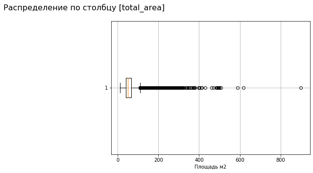

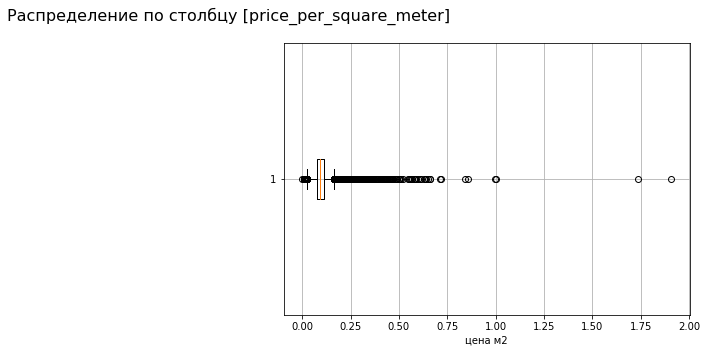

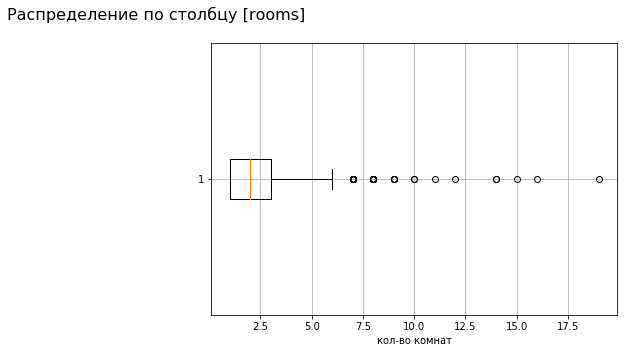

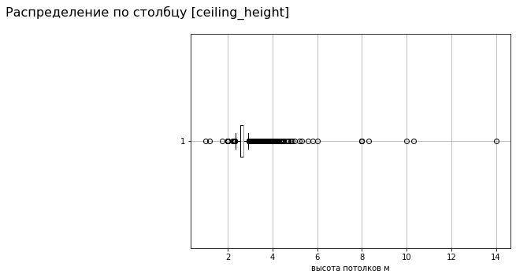

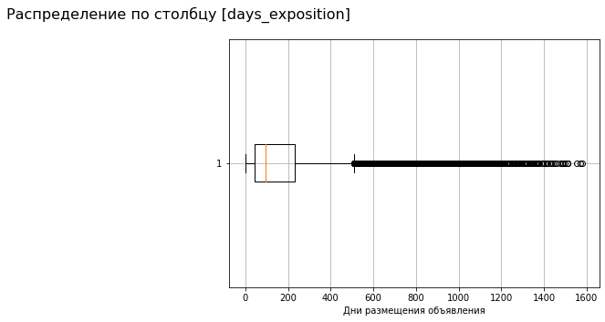

```python
yashik_s_ysami(df, 'total_area', 100,  'Распределение по столбцу', 'Площадь м2') # площадь
yashik_s_ysami(df, 'price_per_square_meter', 1000,  'Распределение по столбцу', 'цена м2') # цена за м2.
yashik_s_ysami(df, 'rooms', 20, 'Распределение по столбцу', 'кол-во комнат') # кол-во комнат
yashik_s_ysami(df, 'ceiling_height', 100, 'Распределение по столбцу', 'высота потолков м') # высота потолков
yashik_s_ysami(df, 'days_exposition', 100,  'Распределение по столбцу', 'Дни размещения объявления') # дни размещения объявления
```

В размах "усов" попадали нормальные значения, а за его пределами - выбросы, изображенные точками. Правый ус длинее левого, значит графики заканчиваются максимумом. Проверим значения каждого столбца через функцию `describe()` и удалим выбросы:

Для столбца `total_area`

```python
df['total_area'].describe() # узнаем значения столбца
```

```
count    20394.000000
mean        58.834265
std         34.066200
min         12.000000
25%         39.500000
50%         50.800000
75%         67.800000
max        900.000000
Name: total_area, dtype: float64
```

```python
df = (df.query('total_area <99')).reset_index(drop=True) # удалим все значения, которые больше 99
```

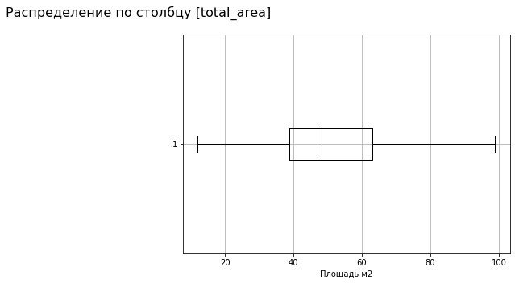

```python
yashik_s_ysami(df, 'total_area', 100,  'Распределение по столбцу', 'Площадь м2') #проверим площадь без выбросов
```

Для столбца `price_per_square_meter`:

```python
df['price_per_square_meter'].describe() # узнаем значения
```

```
count    18929.000000
mean         0.094261
std          0.034220
min          0.007407
25%          0.075567
50%          0.093103
75%          0.110032
max          0.640084
Name: price_per_square_meter, dtype: float64
```

```python
df = (df.query('0.03 < price_per_square_meter < 0.155')).reset_index(drop=True) # удалим все строки, в которых значение м2 больше 154 тыс.
```

После замены на млн. Пришлось высчитывать вот так

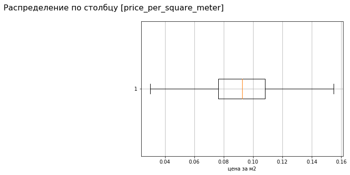

```python
yashik_s_ysami(df, 'price_per_square_meter', 500,  'Распределение по столбцу', 'цена за м2') #проверим цену м2. без выбросов
```

Для столбца `rooms`:

```python
df['rooms'].describe()
```

```
count    17912.000000
mean         1.883933
std          0.849704
min          1.000000
25%          1.000000
50%          2.000000
75%          3.000000
max          6.000000
Name: rooms, dtype: float64
```

```python
df = (df.query('rooms <4')).reset_index(drop=True) # удалим все строки, в которых кол-во комнат больше 3.
```

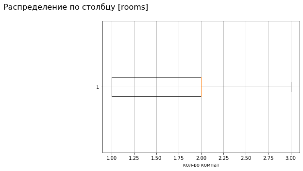

```python
yashik_s_ysami(df, 'rooms', 20, 'Распределение по столбцу', 'кол-во комнат')  # Проверим
```

Для столбца `ceiling_height`:

```python
df['ceiling_height'].describe()
```

```
count    17420.000000
mean         2.673595
std          0.215912
min          1.000000
25%          2.550000
50%          2.700000
75%          2.700000
max         14.000000
Name: ceiling_height, dtype: float64
```

```python
df = (df.query('2.3 < ceiling_height < 2.9')).reset_index(drop=True) # удалим все строки, в которых высота потолков менее 2.3м и более 2.9
```

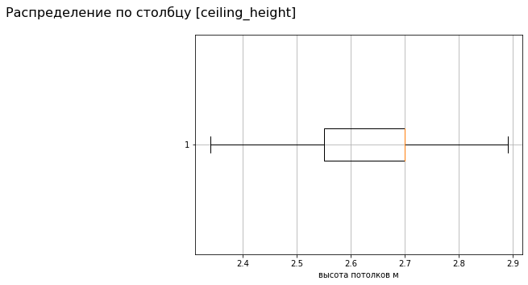

```python
yashik_s_ysami(df, 'ceiling_height', 100, 'Распределение по столбцу', 'высота потолков м') # Проверим
```

Для столбца `days_exposition`:

```python
df['days_exposition'].describe()
```

```
count    16171.000000
mean       167.127945
std        205.820579
min          1.000000
25%         42.000000
50%         89.000000
75%        210.000000
max       1580.000000
Name: days_exposition, dtype: float64
```

Имеются данные с 1580 днями (более 4 лет). Такое в принципе возможно, но такие данные будут негативно влиять на следующие анализы данных. Удалим их:

```python
df = (df.query('days_exposition < 250')).reset_index(drop=True) # удалим все строки, в которых объявления простояли более 250 дней.
```

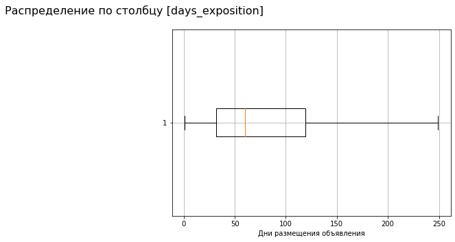

```python
yashik_s_ysami(df, 'days_exposition', 100,  'Распределение по столбцу', 'Дни размещения объявления') # Проверим
```

На данном этапе были выявлены и удалены всё выбросы с помощью блочного графика

### Факторы которые больше всего влияют на стоимость квартиры.

Посчитаем корреляцию для нужных параметров:

```python
df[['last_price', 'price_per_square_meter', 'total_area', 'rooms', 'cityCenters_nearest']].corr()
```

|  | last_price | price_per_square_meter | total_area | rooms | cityCenters_nearest |
| --- | --- | --- | --- | --- | --- |
| last_price | 1.000000 | 0.603509 | 0.732674 | 0.473377 | -0.297734 |
| price_per_square_meter | 0.603509 | 1.000000 | -0.059065 | -0.208403 | -0.418239 |
| total_area | 0.732674 | -0.059065 | 1.000000 | 0.805779 | -0.083058 |
| rooms | 0.473377 | -0.208403 | 0.805779 | 1.000000 | -0.041647 |
| cityCenters_nearest | -0.297734 | -0.418239 | -0.083058 | -0.041647 | 1.000000 |

Отрисуем диаграммы компактно при помощи удобного метода sns.pairplot - он разместит графики единым полотном

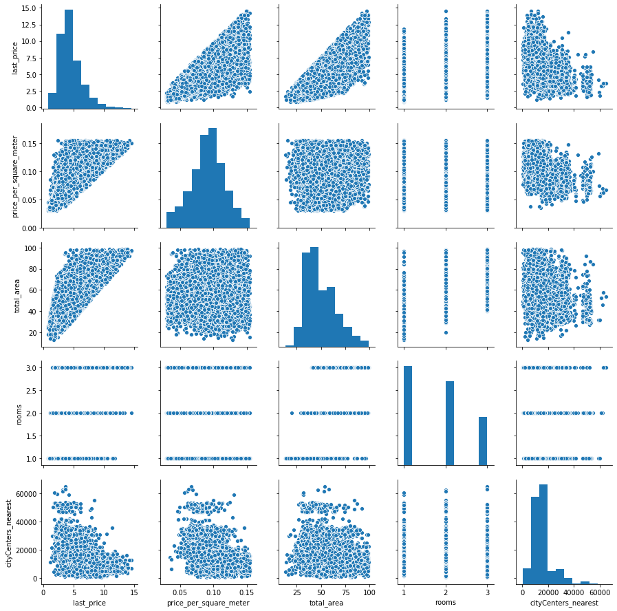

```python
sns.pairplot(df[['last_price', 'price_per_square_meter', 'total_area', 'rooms', 'cityCenters_nearest']]);
```

По таблице можно уже сделать выводы о зависимостях и корреляции. Но для более точного ответа на поставленные цели, изучим ,более подробно зависимости основных столбцов:

#### Как зависит цена от площади, числа комнат, удалённости от центра.

Изучим зависимость цены от общей площади:

```
0.7326744824000214
```

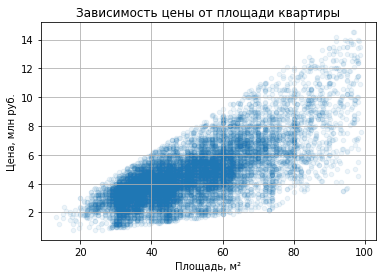

```python
print(df['last_price'].corr(df['total_area'])) # Выведем коррелияцию в цифрах
df.plot(x='total_area', y='last_price', kind='scatter', grid=True, alpha=0.08) # Построим график
plt.title('Зависимость цены от площади квартиры', size=12)
plt.xlabel('Площадь, м²')
plt.ylabel('Цена, млн руб.')
plt.show()
```

Изучим зависимость цены от числа комнат:

```
0.47337679773518043
```

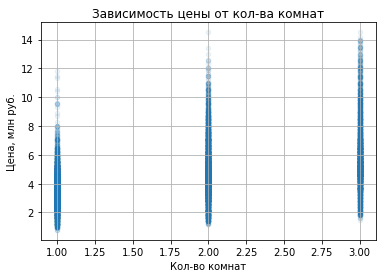

```python
print(df['last_price'].corr(df['rooms']))
df.plot(x='rooms', y='last_price', kind='scatter', grid=True, alpha=0.08)
plt.title('Зависимость цены от кол-ва комнат', size=12)
plt.xlabel('Кол-во комнат')
plt.ylabel('Цена, млн руб.')
plt.show()
```

Зависимость цены от удаленности от центра:

```
-0.2977344242639785
```

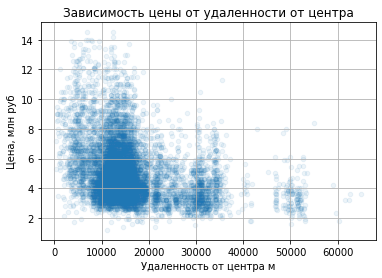

```python
print(df['last_price'].corr(df['cityCenters_nearest']))
df.plot(x='cityCenters_nearest', y='last_price', kind='scatter', grid=True, alpha=0.08)
plt.title('Зависимость цены от удаленности от центра', size=12)
plt.xlabel('Удаленность от центра м')
plt.ylabel('Цена, млн руб')
plt.show()
```

#### Как зависит цена от того, на каком этаже расположена квартира: первом, последнем или другом

Изучим зависимость:

```
(0.015, 0.2)
```

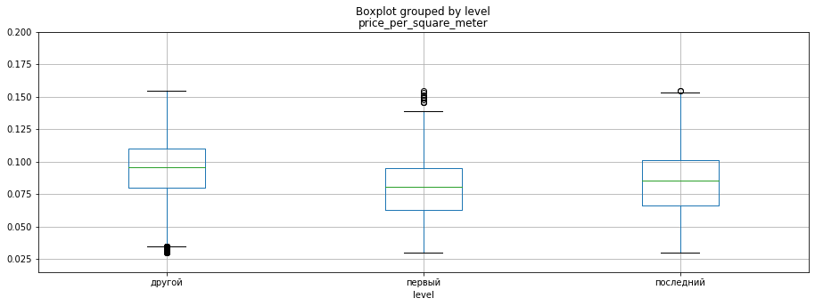

```python
df.boxplot(column = 'price_per_square_meter', by = 'level', figsize=(15,5))
plt.ylim(0.015, 0.2)
```

График, показывает, что медианная цена м2. для квартир на первых и последних этажах немного ниже, чем на остальных.

#### Как зависит цена от даты размещения: дня недели, месяца и года

Изучим зависимость:

```
(0.015, 0.2)
```

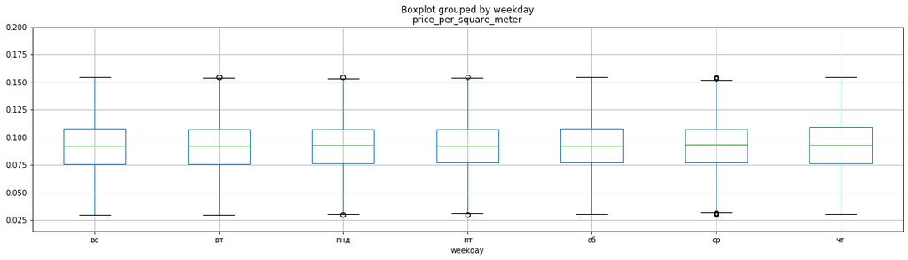

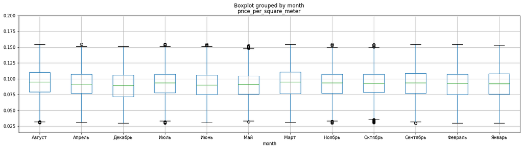

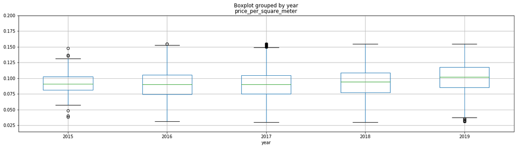

```python
df.boxplot(column = 'price_per_square_meter', by = 'weekday', figsize = (20,5))
plt.ylim(0.015, 0.2)
df.boxplot(column = 'price_per_square_meter', by = 'month', figsize = (20,5))
plt.ylim(0.015, 0.2)
df.boxplot(column = 'price_per_square_meter', by = 'year', figsize = (20,5))
plt.ylim(0.015, 0.2)
```

### Выберите 10 населённых пунктов с наибольшим числом объявлений.

Сделаем новую сводную таблицу с 10 населенными пунктами и посчитаем среднюю цену м2:

```python
large_settlements = df.groupby('locality_name')['price_per_square_meter'].agg(['mean','count']).sort_values(by='count', ascending=False) # Сгруппируем и посчитаем среднюю цену и кол-во объявлений
large_settlements = large_settlements.rename(columns={'mean':'Средняя цена', 'count':'Кол-во объявлений'}) # Переименуем столбцы для удобства анализирования
large_settlements.index = large_settlements.index.rename('Название населенного пункта')
large_settlements = large_settlements.head(10)
large_settlements
```

| Название населенного пункта | Средняя цена | Кол-во объявлений |
| --- | --- | --- |
| Санкт-Петербург | 0.103143 | 8157 |
| посёлок Мурино | 0.086476 | 426 |
| посёлок Шушары | 0.078211 | 322 |
| посёлок Парголово | 0.089361 | 239 |
| Колпино | 0.075277 | 229 |
| Всеволожск | 0.066978 | 229 |
| деревня Кудрово | 0.092918 | 224 |
| Пушкин | 0.098320 | 187 |
| Гатчина | 0.068987 | 183 |
| Выборг | 0.058575 | 137 |

### Изучите предложения квартир.

Выясним, какая область входит в центр. Первым делом выделим квартиры в Санкт-Петербурге:

```python
spb = df.query('locality_name == "Санкт-Петербург"')
```

Создадим столбец с расстоянием до центра в км и округлим до целых значений:

```python
spb['cityCenters_nearest_km'] = (df['cityCenters_nearest']/1000).round(0) # Переводим в км. и убираем знаки после запятой
```

```python
km_mean = spb.pivot_table(index = 'cityCenters_nearest_km', values = 'price_per_square_meter', aggfunc = ['mean','count']) # Средняя цена за каждый км от "точки центра города"
km_mean.columns = ['средняя цена за м2', 'кол-во']
km_mean.head()
```

| cityCenters_nearest_km | средняя цена за м2 | кол-во |
| --- | --- | --- |
| 0.0 | 0.099082 | 2 |
| 1.0 | 0.114200 | 26 |
| 2.0 | 0.112679 | 42 |
| 3.0 | 0.110270 | 67 |
| 4.0 | 0.114492 | 129 |

По вышеперечисленным значениям, построим график, чтобы определить, как цена зависит от удалённости от центра. Далее определим границу, где график сильно меняется, — это и будет центральная зона.

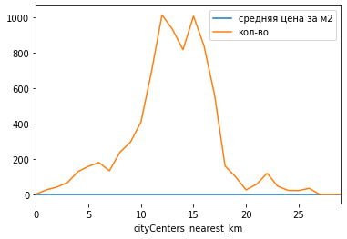

```python
km_mean.plot();
```

### Выделим сегмент квартир в центре

#### Проализируем центр города, и изучим следующие параметры: площадь, цена, число комнат, высота потолков:

```python
spb_center = spb.query('cityCenters_nearest_km <= 7') # Новый DF, в котором квартиры находятся только в цетре города.
spb_center = spb_center.rename(columns={'total_area':'Площадь','last_price':'Цена', 'rooms':'кол-во комнат','ceiling_height':'высота потолков','floor':'этаж','cityCenters_nearest':'удаленность от центра','weekday':'день недели', 'month':'месяц','year':'год'}) # Переименуем
column = ['Цена','Площадь','кол-во комнат','высота потолков', 'удаленность от центра']
column_second = ['Цена','кол-во комнат', 'этаж', 'удаленность от центра','год']
```

```python
spb_center[column].corr() # Выведем корреляцию
```

|  | Цена | Площадь | кол-во комнат | высота потолков | удаленность от центра |
| --- | --- | --- | --- | --- | --- |
| Цена | 1.000000 | 0.820423 | 0.512361 | 0.219056 | -0.088200 |
| Площадь | 0.820423 | 1.000000 | 0.747499 | 0.225919 | -0.166616 |
| кол-во комнат | 0.512361 | 0.747499 | 1.000000 | 0.095573 | -0.159832 |
| высота потолков | 0.219056 | 0.225919 | 0.095573 | 1.000000 | -0.226312 |
| удаленность от центра | -0.088200 | -0.166616 | -0.159832 | -0.226312 | 1.000000 |

Изучим зависимость цены от общей площади:

```
0.8204229310126587
```

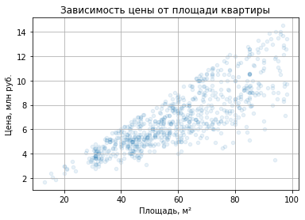

```python
print(spb_center['Цена'].corr(spb_center['Площадь'])) # Выведем коррелияцию в цифрах
spb_center.plot(x='Площадь', y='Цена', kind='scatter', grid=True, alpha=0.1) # Построим график
plt.title('Зависимость цены от площади квартиры', size=12)
plt.xlabel('Площадь, м²')
plt.ylabel('Цена, млн руб.')
plt.show()
```

Изучим зависимость цены от числа комнат:

```
0.5123614074033453
```

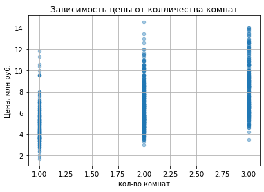

```python
print(spb_center['Цена'].corr(spb_center['кол-во комнат'])) # Выведем коррелияцию в цифрах
spb_center.plot(x='кол-во комнат', y='Цена', kind='scatter', grid=True, alpha=0.4) # Построим график
plt.title('Зависимость цены от колличества комнат', size=12)
plt.xlabel('кол-во комнат')
plt.ylabel('Цена, млн руб.')
plt.show()
```

Зависимость цены от высоты потолков:

```
0.21905599858870042
```

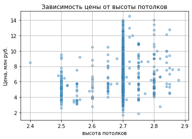

```python
print(spb_center['Цена'].corr(spb_center['высота потолков'])) # Выведем коррелияцию в цифрах
spb_center.plot(x='высота потолков', y='Цена', kind='scatter', grid=True, alpha=0.4) # Построим график
plt.title('Зависимость цены от высоты потолков', size=12)
plt.xlabel('высота потолков')
plt.ylabel('Цена, млн руб.')
plt.show()
```

Зависимость от удалённости от центра:

```
-0.08820002727760082
```

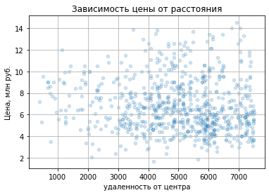

```python
print(spb_center['Цена'].corr(spb_center['удаленность от центра'])) # Выведем коррелияцию в цифрах
spb_center.plot(x='удаленность от центра', y='Цена', kind='scatter', grid=True, alpha=0.2) # Построим график
plt.title('Зависимость цены от расстояния', size=12)
plt.xlabel('удаленность от центра')
plt.ylabel('Цена, млн руб.')
plt.show()
```